# Explore Red Wine Data

# 1 Introduction

In this report, I will explore the red wine dataset. First, I will look at each individual attribute of this dataset and plot its distribution. Second, I will look at two attributes at a time to explore 1) how each input attribute is related to the output attribute–quality; 2) interesting pairs of input attributes. Third, I will examine three attributes by adding one additional attribute to some of the interesting two-attribute pairs. Finally, I will summarize the successes and problems I encounter during the data exploration process.

```r
# Load all of the packages in this code chunk.
library(ggplot2)
```

```r
# Load the Data
wine_reds = read.csv('wineQualityReds.csv', row.names = 1)
```

# 2 Univariate Exploration

In this section, I will first look at the structure of the data set. Then I will examine the distribution of each attribute individually by plotting its distribution.

```r
dim(wine_reds)
```

```
## [1] 1599   12
```

```r
# Convert quality into ordered categorical variable
wine_reds$quality <- ordered(wine_reds$quality)
str(wine_reds)
```

```
## 'data.frame':    1599 obs. of  12 variables:
##  $ fixed.acidity       : num  7.4 7.8 7.8 11.2 7.4 7.4 7.9 7.3 7.8 7.5 ...
##  $ volatile.acidity    : num  0.7 0.88 0.76 0.28 0.7 0.66 0.6 0.65 0.58 0.5 ...
##  $ citric.acid         : num  0 0 0.04 0.56 0 0 0.06 0 0.02 0.36 ...
##  $ residual.sugar      : num  1.9 2.6 2.3 1.9 1.9 1.8 1.6 1.2 2 6.1 ...
##  $ chlorides           : num  0.076 0.098 0.092 0.075 0.076 0.075 0.069 0.065 0.073 0.071 ...
##  $ free.sulfur.dioxide : num  11 25 15 17 11 13 15 15 9 17 ...
##  $ total.sulfur.dioxide: num  34 67 54 60 34 40 59 21 18 102 ...
##  $ density             : num  0.998 0.997 0.997 0.998 0.998 ...
##  $ pH                  : num  3.51 3.2 3.26 3.16 3.51 3.51 3.3 3.39 3.36 3.35 ...
##  $ sulphates           : num  0.56 0.68 0.65 0.58 0.56 0.56 0.46 0.47 0.57 0.8 ...
##  $ alcohol             : num  9.4 9.8 9.8 9.8 9.4 9.4 9.4 10 9.5 10.5 ...
##  $ quality             : Ord.factor w/ 6 levels "3"<"4"<"5"<"6"<..: 3 3 3 4 3 3 3 5 5 3 ...
```

```r
summary(wine_reds)
```

```
##  fixed.acidity   volatile.acidity  citric.acid    residual.sugar
##  Min.   : 4.60   Min.   :0.1200   Min.   :0.000   Min.   : 0.900
##  1st Qu.: 7.10   1st Qu.:0.3900   1st Qu.:0.090   1st Qu.: 1.900
##  Median : 7.90   Median :0.5200   Median :0.260   Median : 2.200
##  Mean   : 8.32   Mean   :0.5278   Mean   :0.271   Mean   : 2.539
##  3rd Qu.: 9.20   3rd Qu.:0.6400   3rd Qu.:0.420   3rd Qu.: 2.600
##  Max.   :15.90   Max.   :1.5800   Max.   :1.000   Max.   :15.500
##    chlorides       free.sulfur.dioxide total.sulfur.dioxide
##  Min.   :0.01200   Min.   : 1.00       Min.   :  6.00
##  1st Qu.:0.07000   1st Qu.: 7.00       1st Qu.: 22.00
##  Median :0.07900   Median :14.00       Median : 38.00
##  Mean   :0.08747   Mean   :15.87       Mean   : 46.47
##  3rd Qu.:0.09000   3rd Qu.:21.00       3rd Qu.: 62.00
##  Max.   :0.61100   Max.   :72.00       Max.   :289.00
##     density             pH          sulphates         alcohol      quality
##  Min.   :0.9901   Min.   :2.740   Min.   :0.3300   Min.   : 8.40   3: 10
##  1st Qu.:0.9956   1st Qu.:3.210   1st Qu.:0.5500   1st Qu.: 9.50   4: 53
##  Median :0.9968   Median :3.310   Median :0.6200   Median :10.20   5:681
##  Mean   :0.9967   Mean   :3.311   Mean   :0.6581   Mean   :10.42   6:638
##  3rd Qu.:0.9978   3rd Qu.:3.400   3rd Qu.:0.7300   3rd Qu.:11.10   7:199
##  Max.   :1.0037   Max.   :4.010   Max.   :2.0000   Max.   :14.90   8: 18
```

The red wine dataset contains 12 variables–11 input numerical variables based on physicochemical tests and 1 categorical output variable (quality) based on sensory data, with 1599 observations.

```r
# Function to plot histogram of a single variable
plot_uni_var <- function(variable, bins = 50) {
  return (ggplot(aes_string(x = variable), data = wine_reds) +
            geom_histogram(bins = bins))
}
```

## 2.1 Quality

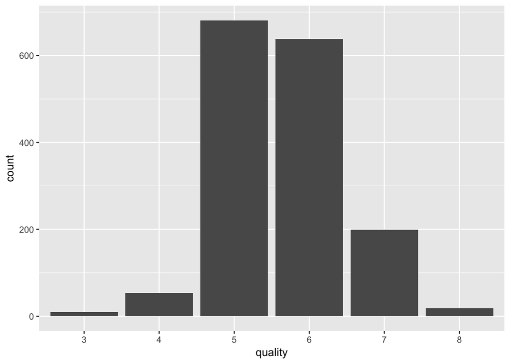

```r
ggplot(aes(x = quality), data = wine_reds) +
  geom_bar()
```

Out of the possible quality scores between 0 and 10, all of our red wines’ quality scores fall between 3 and 8. The dataset is not well balanced. Majority of red wines have a quality score of either 5 or 6. I am curious about what attributes make a wine earn a low quality score (quality = 3) or a high quality score (quality = 8).

## 2.2 Fixed Acidity

Most acids involved with wine are fixed or nonvolatile (do not evaporate readily).

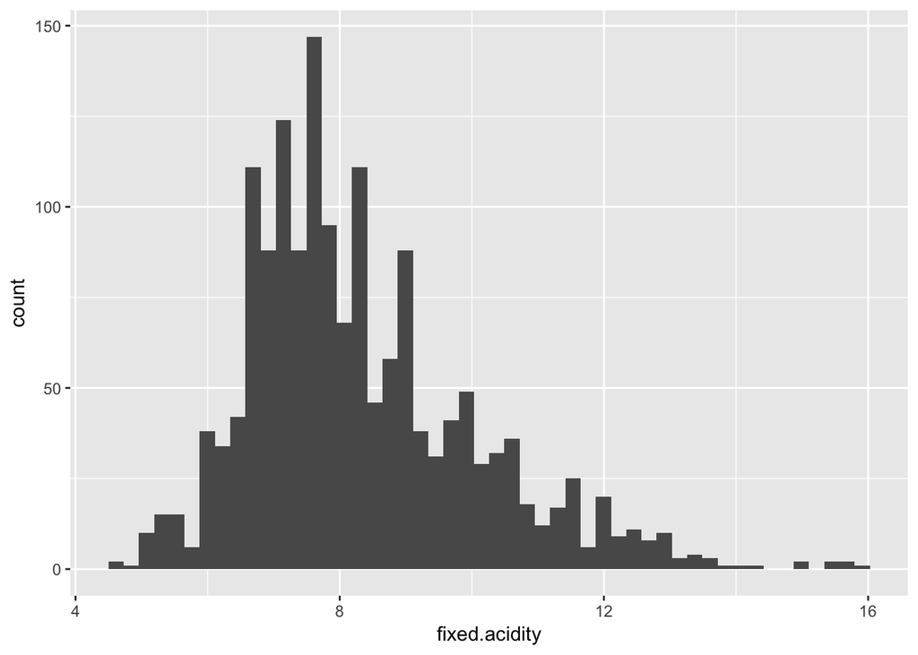

```r
plot_uni_var('fixed.acidity')
```

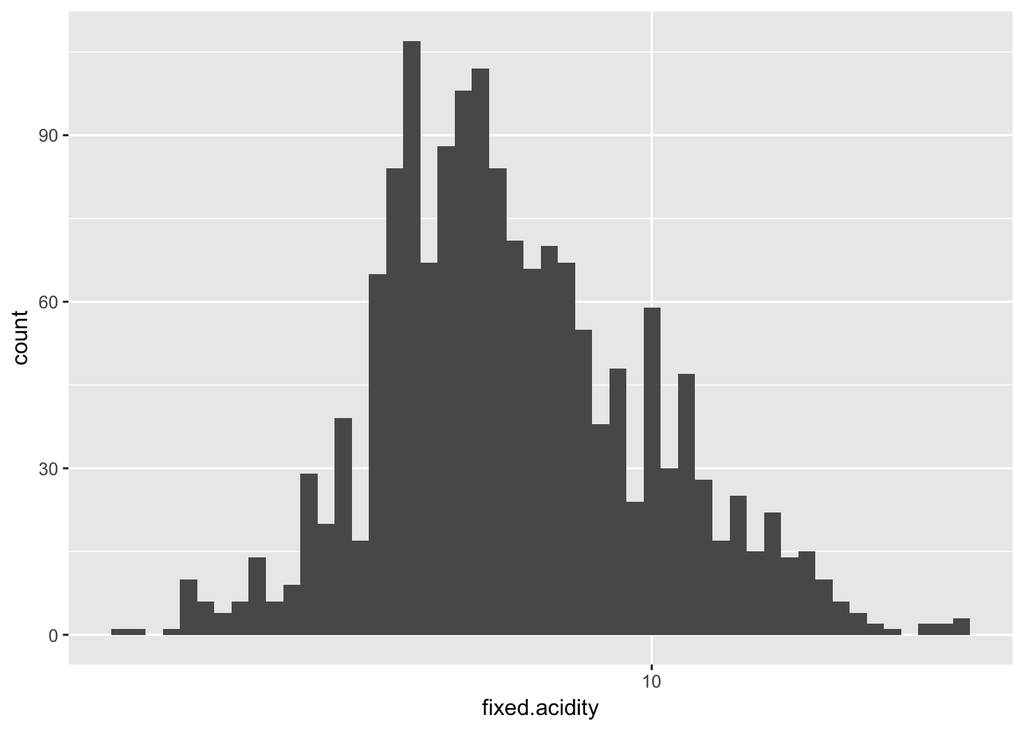

```r
plot_uni_var('fixed.acidity') + scale_x_log10()
```

Fixed acidity values range between 4 and 16, with most values range between 7 and 9. The distribution is slightly positively skewed. Transforming the x-axis into log scale can make it more normally distributed.

## 2.3 Volatile Acidity

The amount of acetic acid in wine, which at too high of levels can lead to an unpleasant, vinegar taste.

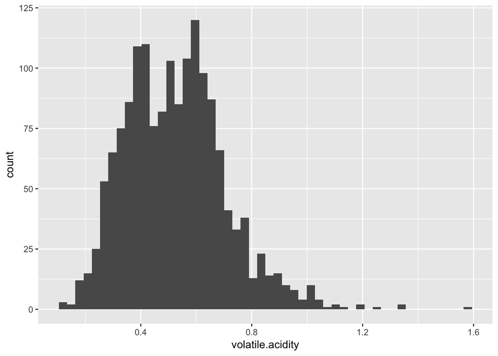

```r
plot_uni_var('volatile.acidity')
```

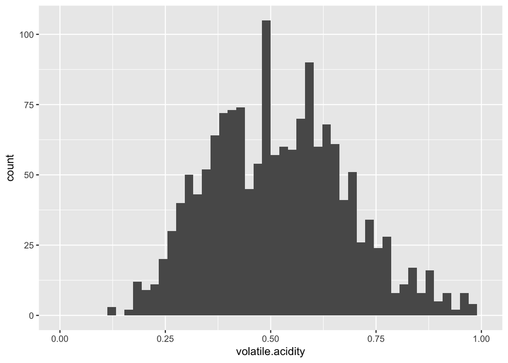

```r
plot_uni_var('volatile.acidity') + scale_x_continuous(limits = c(0, 1))
```

## 2.4 Citric Acid

Found in small quantities, citric acid can add ‘freshness’ and flavor to wines.

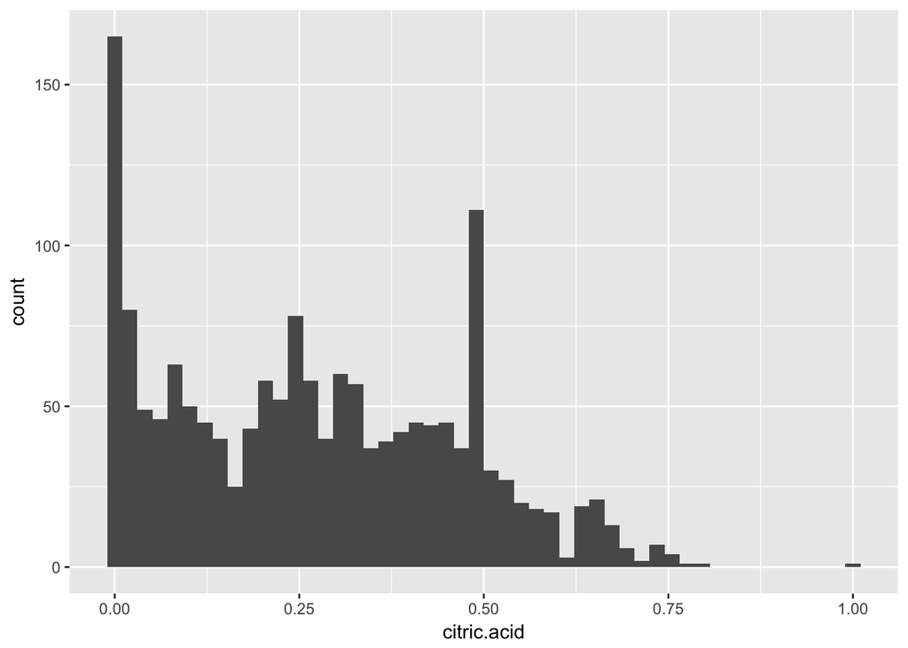

```r
plot_uni_var('citric.acid')
```

```r
# number of red wines with citric acid = 0
dim(wine_reds[wine_reds$citric.acid ==0, ])[1]
```

```
## [1] 132
```

Citric acid values range between 0 and 1 with most values below 0.6. There are 132 red wines in our data set with no detectable citric acid concentration.

## 2.5 Residual Sugar

The amount of sugar remaining after fermentation stops, it is rare to find wines with less than 1 gram/liter and wines with greater than 45 grams/liter are considered sweet.

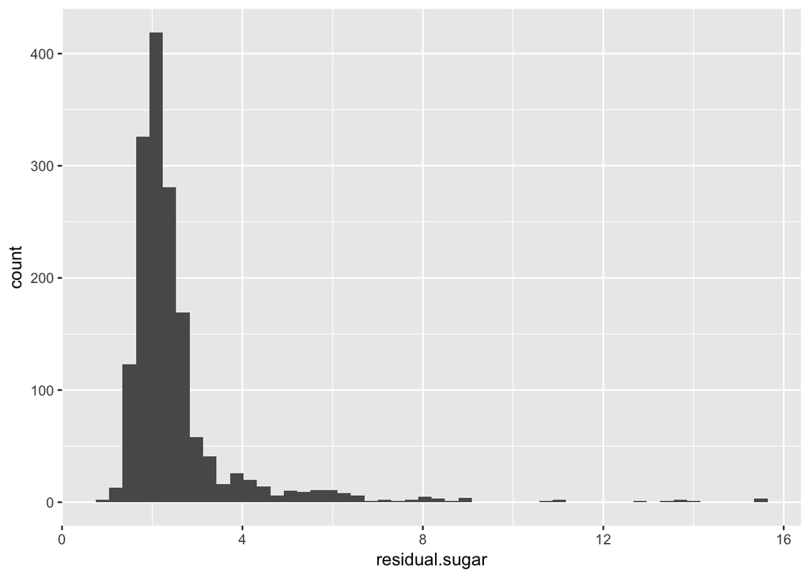

```r
plot_uni_var('residual.sugar')
```

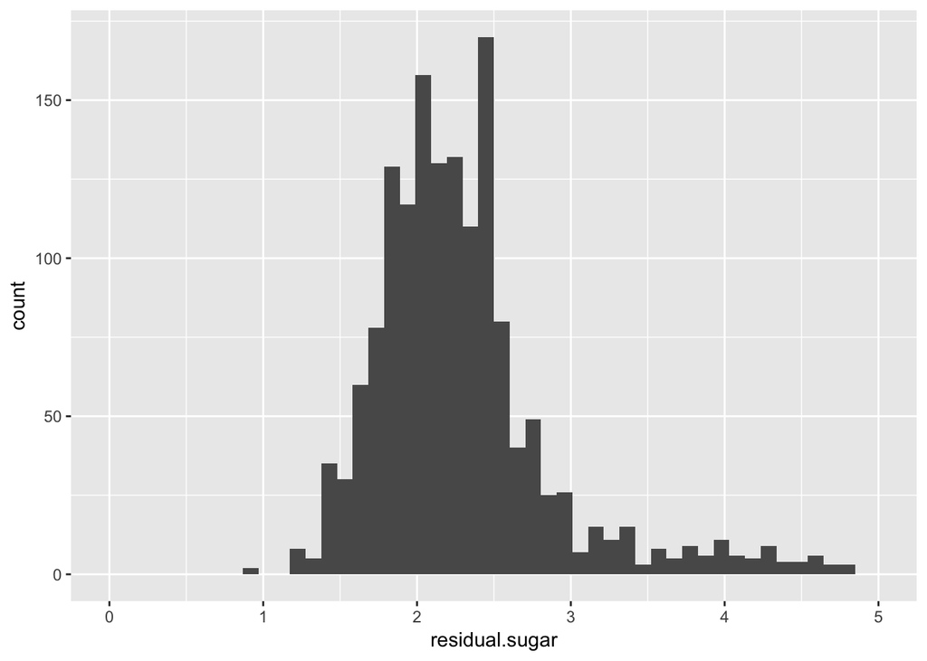

```r
plot_uni_var('residual.sugar') + scale_x_continuous(limits = c(0, 5))
```

Most residual sugar values range between 1.5 and 2.5. There are a few outliers with large values. When zoom in and look at values below 5, the distribution appears normal.

## 2.6 Chlorides

The amount of salt in the wine.

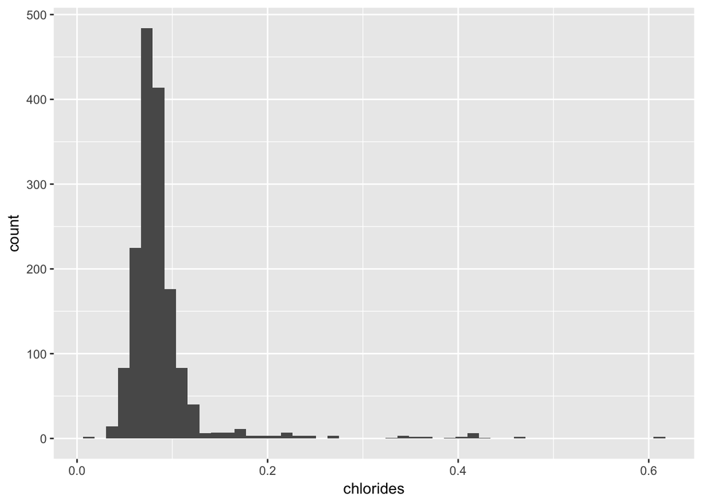

```r
plot_uni_var('chlorides')
```

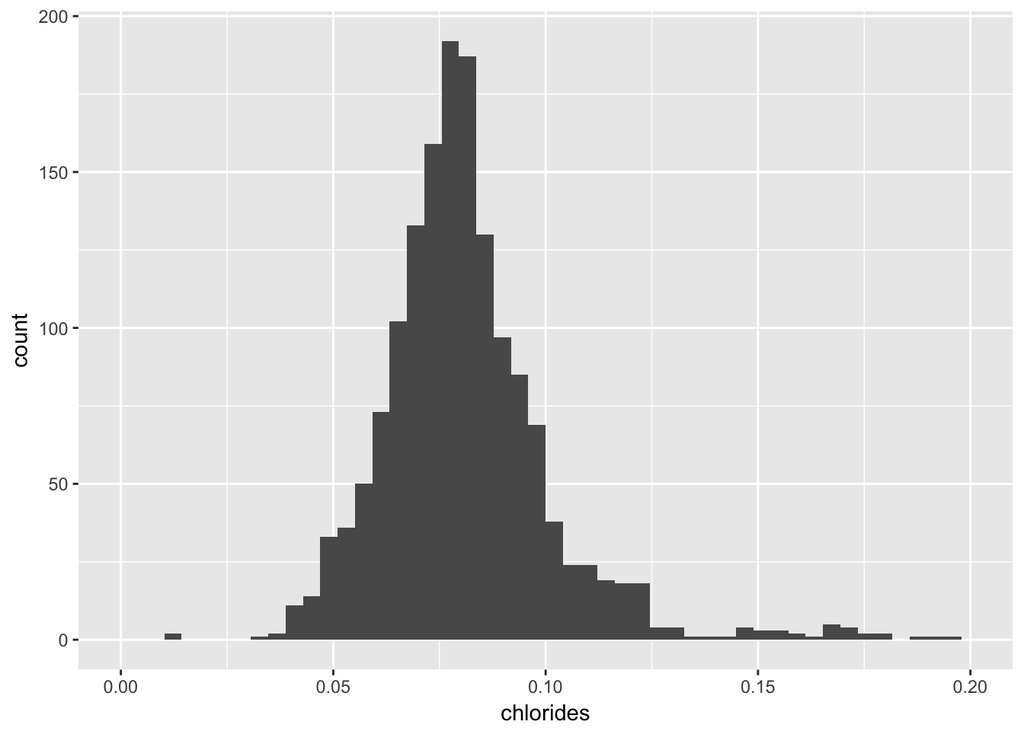

```r
plot_uni_var('chlorides') + scale_x_continuous(limits = c(0, 0.2))
```

Most chlorides values range between 0.05 to 0.1. There are a few outliers with large values. When zoom in and look at values below 0.2, the distribution appears normal.

## 2.7 Free Sulfur Dioxide

The free form of SO2 exists in equilibrium between molecular SO2 (as a dissolved gas) and bisulfite ion; it prevents microbial growth and the oxidation of wine.

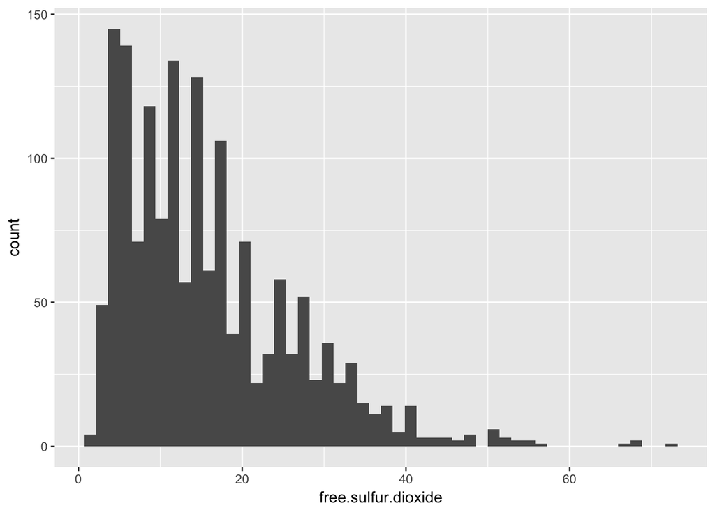

```r
plot_uni_var('free.sulfur.dioxide')
```

The distribution of free sulfur dioxide is highly positively skewed.

## 2.8 Total Sulfur Dioxide

The amount of free and bound forms of S02; in low concentrations, SO2 is mostly undetectable in wine, but at free SO2 concentrations over 50 ppm, SO2 becomes evident in the nose and taste of wine.

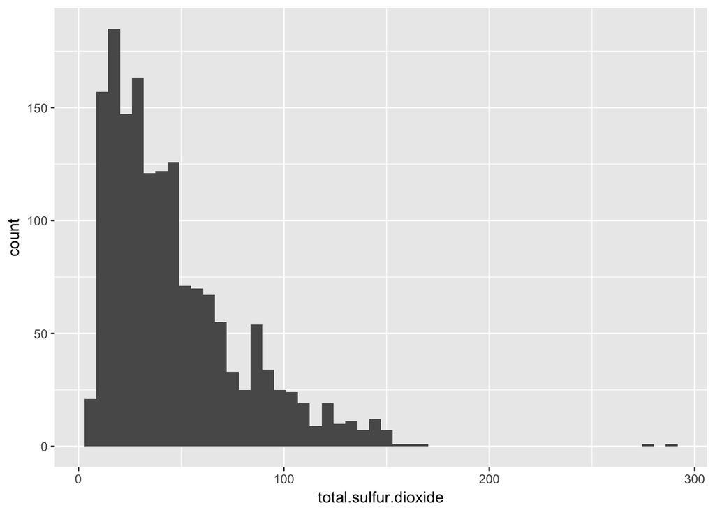

```r
plot_uni_var('total.sulfur.dioxide')
```

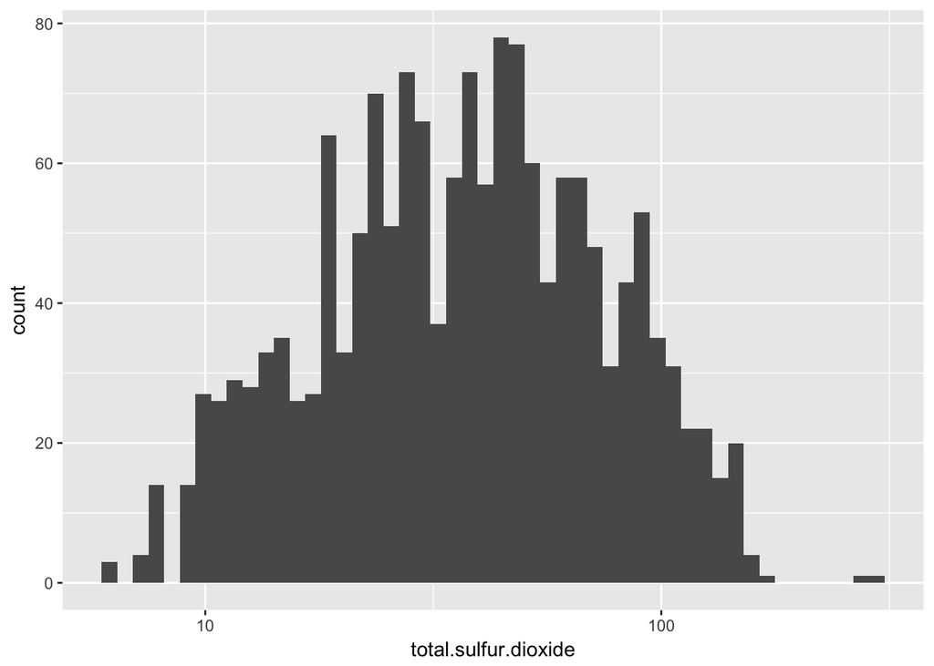

```r
plot_uni_var('total.sulfur.dioxide') + scale_x_log10()
```

The distribution of total sulfur dioxide is higly positively skewed. And there are a few outliers with very large values. Transforming the x-axis into log scale can make it more normally distributed.

## 2.9 Density

The density of wine is close to that of water depending on the percent alcohol and sugar content.

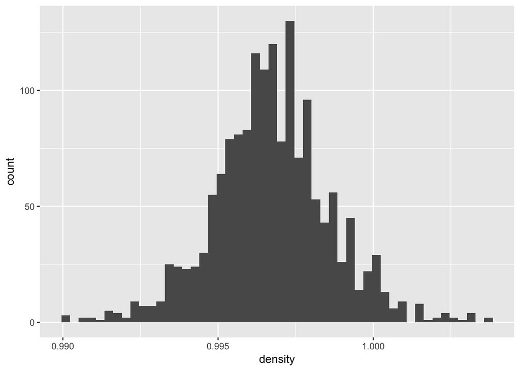

```r
plot_uni_var('density')
```

Density values range between 0.990 and 1.004 with most values range from 0.995 and 0.998. The distribution of density values are symmetrical centered around 0.9965.

## 2.10 pH

Describes how acidic or basic a wine is on a scale from 0 (very acidic) to 14 (very basic); most wines are between 3-4 on the pH scale.

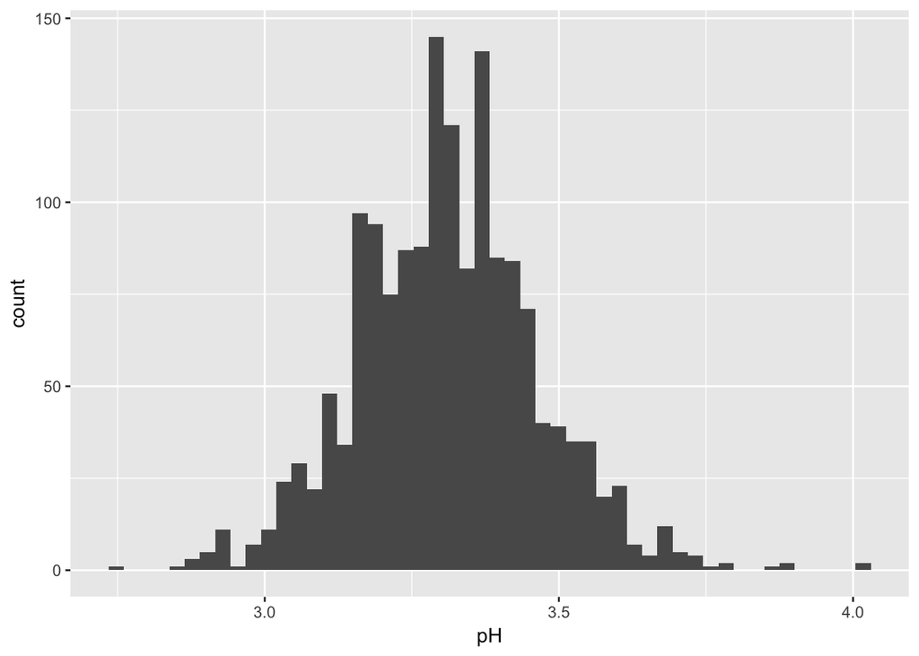

```r
plot_uni_var('pH')
```

Most pH values range between 3.15 and 3.45. The distribution of pH is symmetrical centered around 3.3.

## 2.11 Sulphates

A wine additive which can contribute to sulfur dioxide gas (S02) levels, wich acts as an antimicrobial and antioxidant.

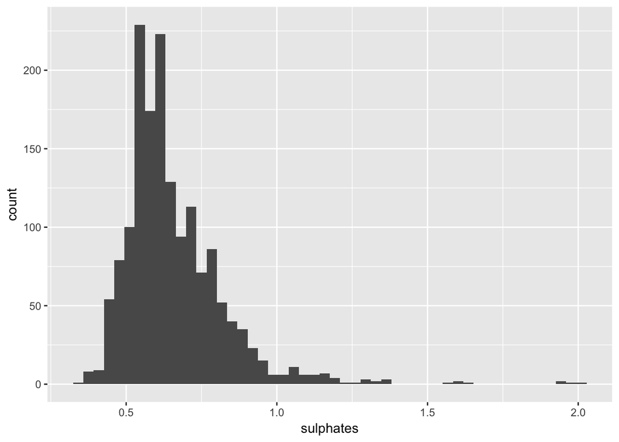

```r
plot_uni_var('sulphates')
```

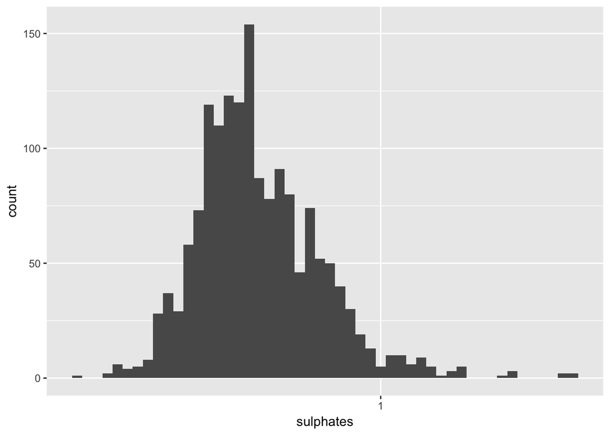

```r
plot_uni_var('sulphates') + scale_x_log10()
```

Most sulphates values range between 0.5 and 0.75. The distribution is positively skewed. There are a few ourliers with large sulphates values. Transforming the x-axis into log scale can make it more normally distributed.

## 2.12 Alcohol

The percent alcohol content of the wine

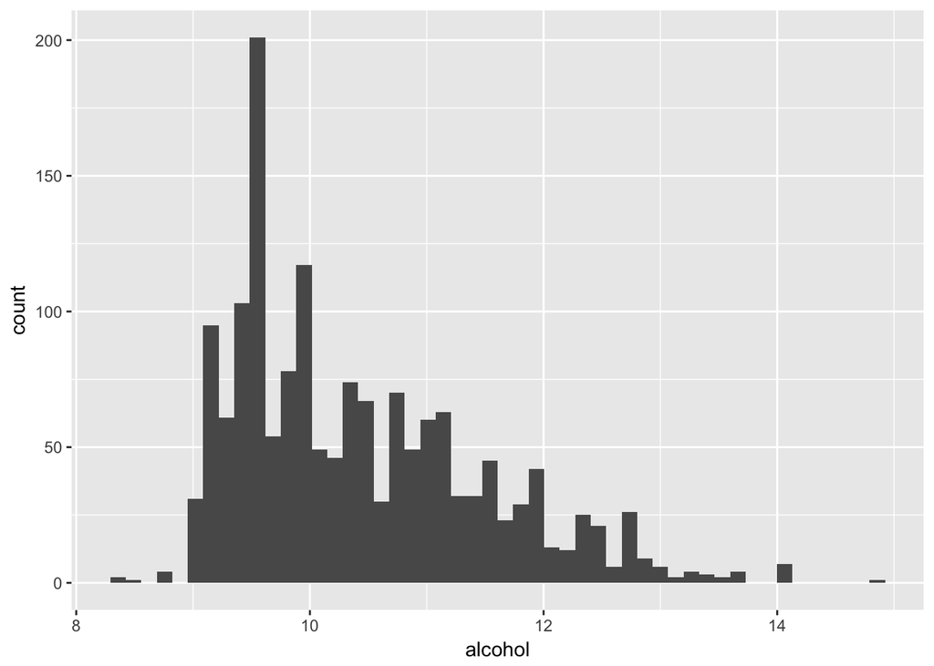

```r
plot_uni_var('alcohol')
```

The alcohol values range between 8.5 and 15. The distribution of alcohol value is positively skewed.

# 3 Univariate Analysis

**What is the structure of your dataset?**

There are 12 attributes in the dataset. 11 of them (fixed acidity, volatile acidity, citric acid, residual sugar, chlorides, free sulfur dioxide, total sulfur dioxide, density, pH, sulphates, alcohol) are input attributes based on physicochemical tests. The other attribute (quality) is the output attribute based on sensory data. Each row corresponds to one particular wine with total 1599 different red wines in the data set.

**What is/are the main feature(s) of interest in your dataset?**

The main feature of interest is the output attribute quality. I am trying to figure out which of the 11 input attribute contribute to a high quality value.

**What other features in the dataset do you think will help support your investigation into your feature(s) of interest?**

The 11 input attributes are equally likely to contribute to the quality value at this point. I will look more closely at how each of the attributes is distributed with a given quality value in the bivariate exploration section.

**Did you create any new variables from existing variables in the dataset?**

No.

**Of the features you investigated, were there any unusual distributions? Did you perform any operations on the data to tidy, adjust, or change the form of the data? If so, why did you do this?**

The possible quality values are from 0 to 10, but our data set only has quality values from 3 to 8, which means there are no extremely bad red wines or extrememly good wines in out data set. The vast majority of red wines in the data set has a quality value either 5 or 6, with very fewer wines with quality values 3, 4, 7 or 8, which makes the data set unbalanced.

# 4 Bivariate Exploration Part I

In this section, I will look at how each input attribute is related to the output quanlity variable.

```r
# Function to plot boxplot of variable grouped by quality
plot_quality_vs_var <- function(variable) {
  # Uncomment the next line to print a summary of variable grouped by quality values
  # print (by(wine_reds[[variable]], wine_reds$quality, summary))
  return (ggplot(aes_string(x = 'quality', y = variable), data = wine_reds) +
            geom_boxplot())
}
```

## 4.1 Quality vs Fixed Acidity

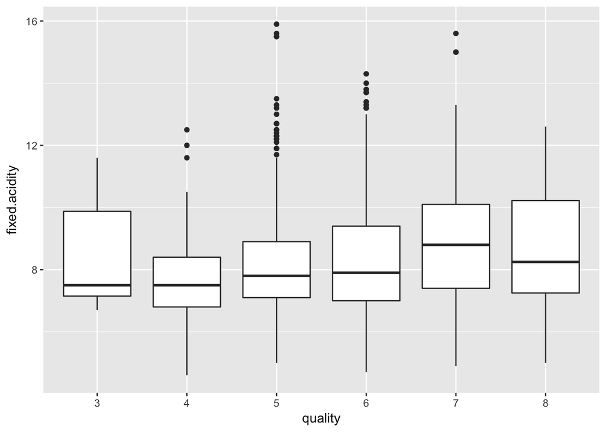

```r
plot_quality_vs_var('fixed.acidity')
```

There isn’t a clear trend between fixed acidity and quality.

## 4.2 Quality vs Volatile Acidity

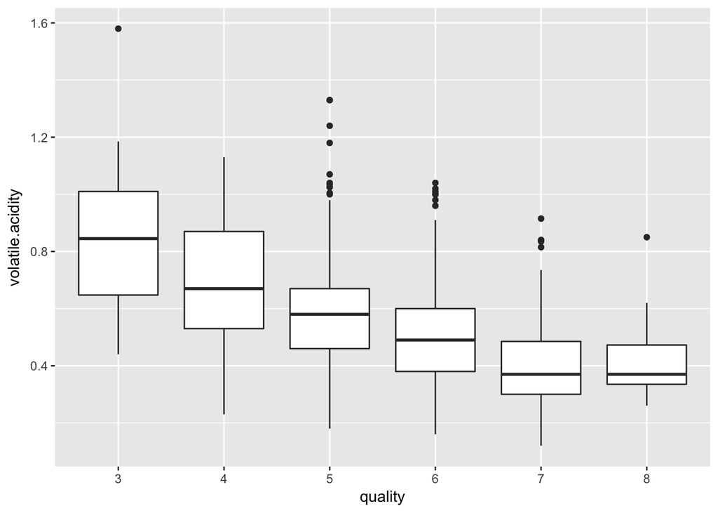

```r
plot_quality_vs_var('volatile.acidity')
```

The higher the quality, the lower the volatile acidity.

## 4.3 Quality vs Citric Acid

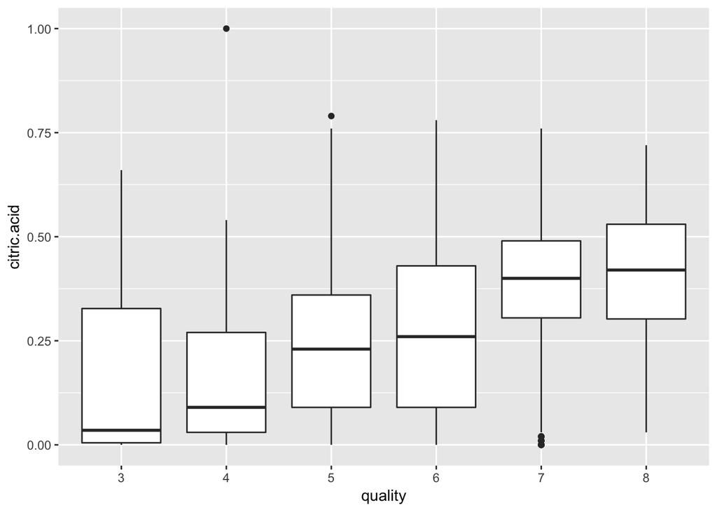

```r
plot_quality_vs_var('citric.acid')
```

The higher the quality, the higher the citric acid.

## 4.4 Quality vs Residual Sugar

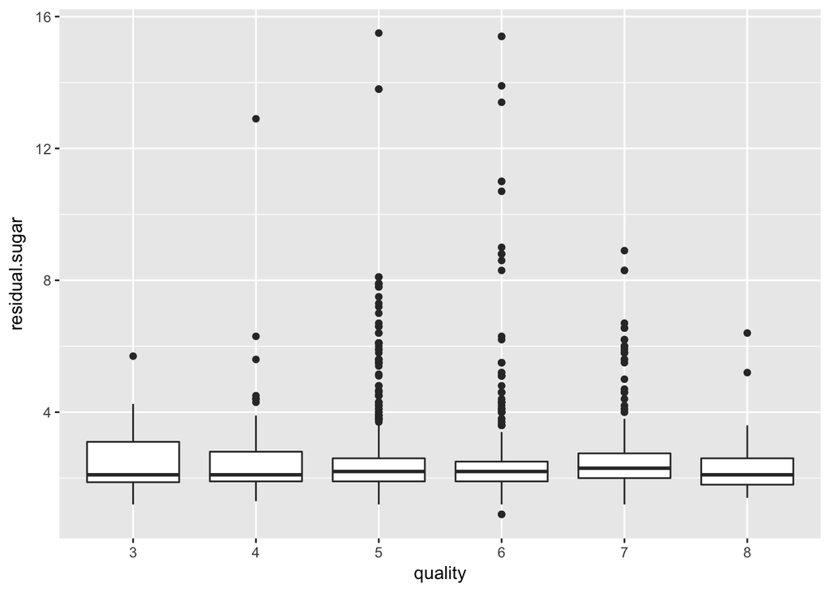

```r
plot_quality_vs_var('residual.sugar')
```

There isn’t a clear trend between residual sugar and quality.

## 4.5 Quality vs Chlorides

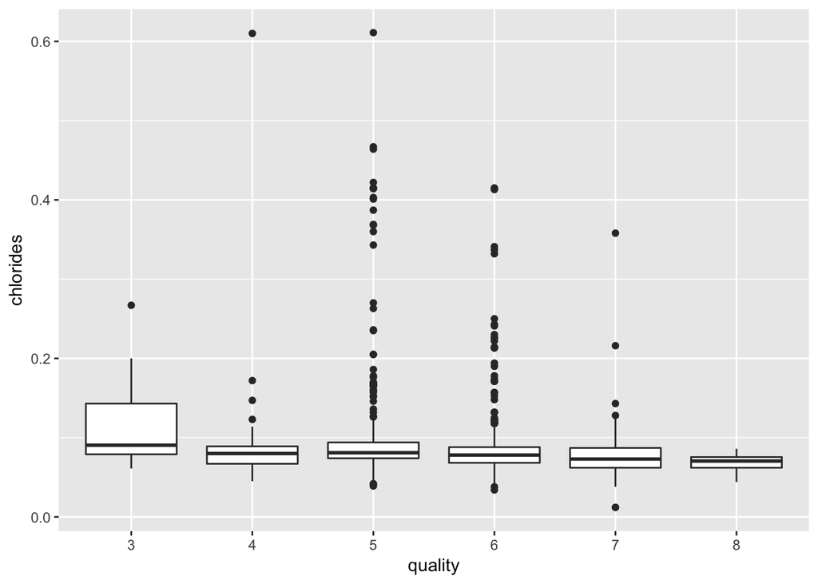

```r
plot_quality_vs_var('chlorides')
```

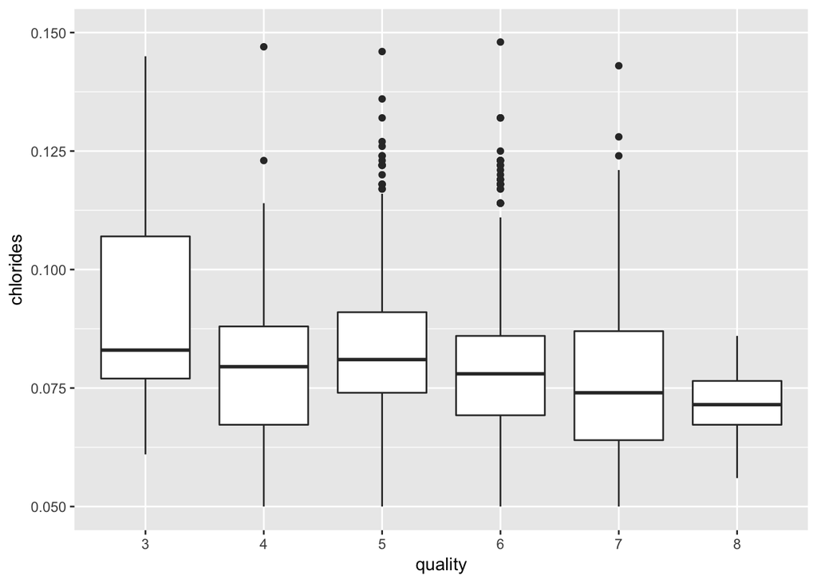

```r
plot_quality_vs_var('chlorides') + scale_y_continuous(limits = c(0.05, 0.15))
```

After zoom in, one can see the higher the quality, the lower the chlorides.

## 4.6 Quality vs Free Sulfur Dioxide

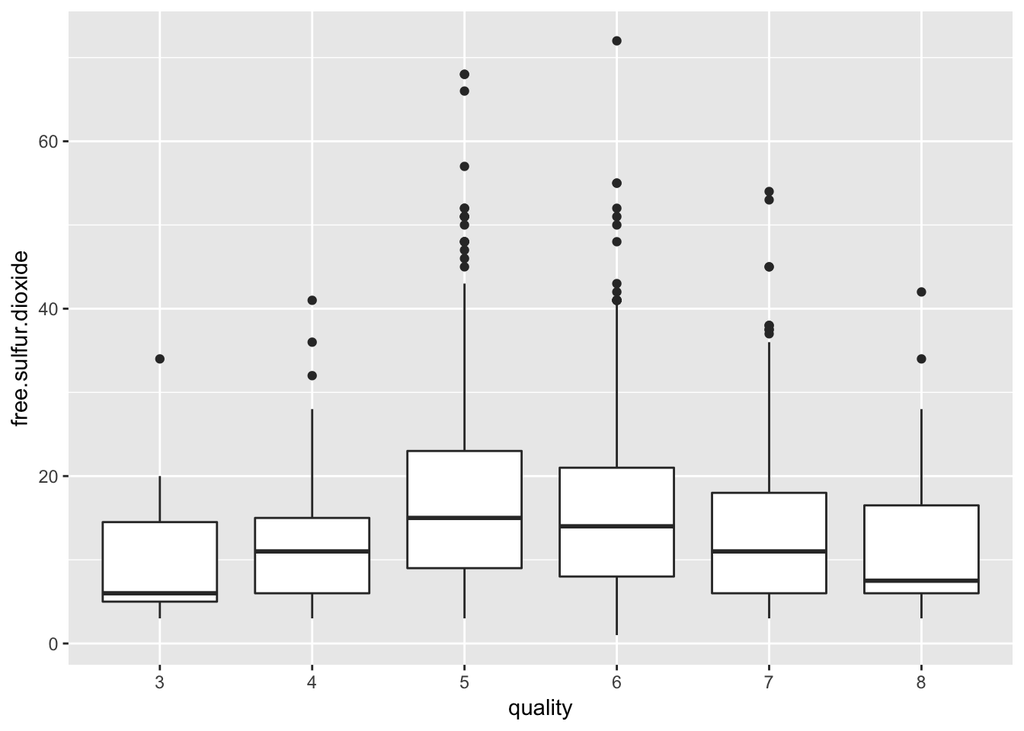

```r
plot_quality_vs_var('free.sulfur.dioxide')
```

There isn’t a clear trend between free sulfur dioxide and quality.

## 4.7 Quality vs Total Sulfur Dioxide

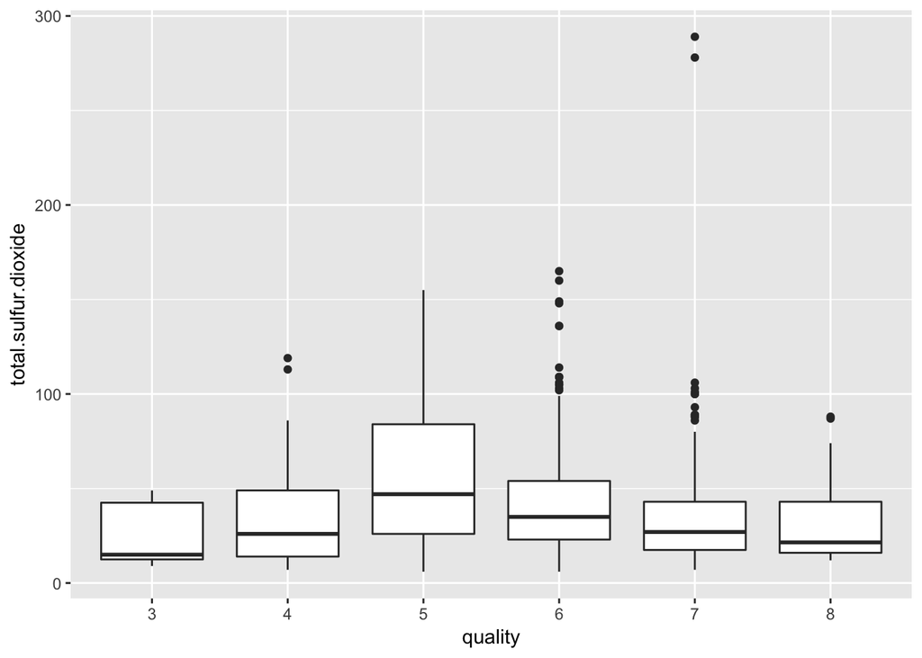

```r
plot_quality_vs_var('total.sulfur.dioxide')
```

There isn’t a clear trend between total sulfur dioxide and quality.

## 4.8 Quality vs Density

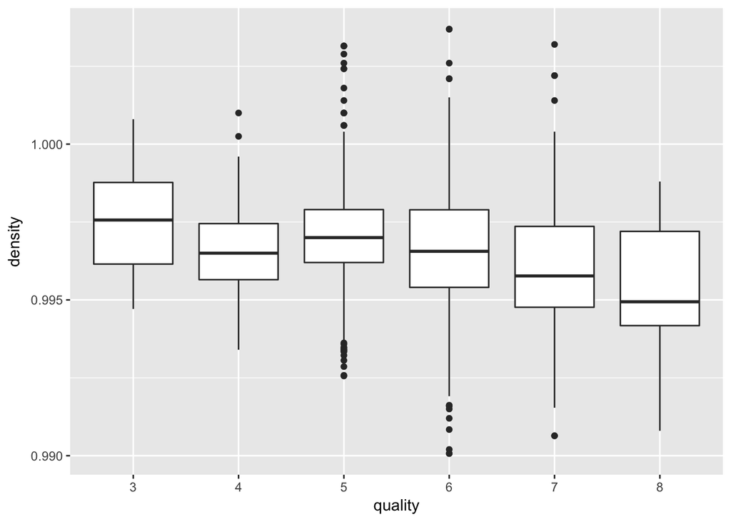

```r
plot_quality_vs_var('density')
```

The higher the quality, the lower the density.

## 4.9 Quality vs pH

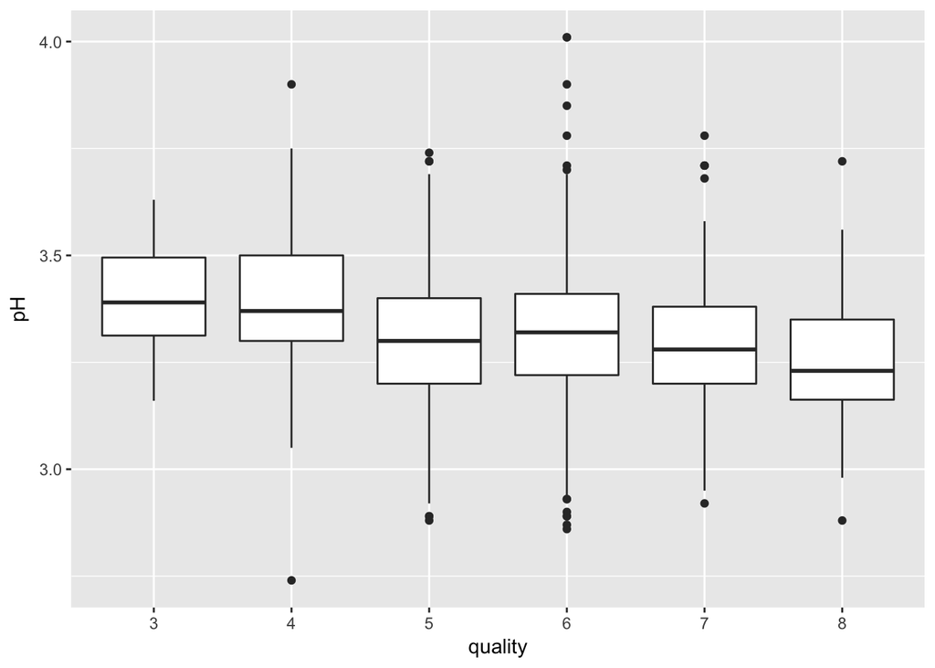

```r
plot_quality_vs_var('pH')
```

The higher the quality, the lower the pH.

## 4.10 Quality vs Sulphates

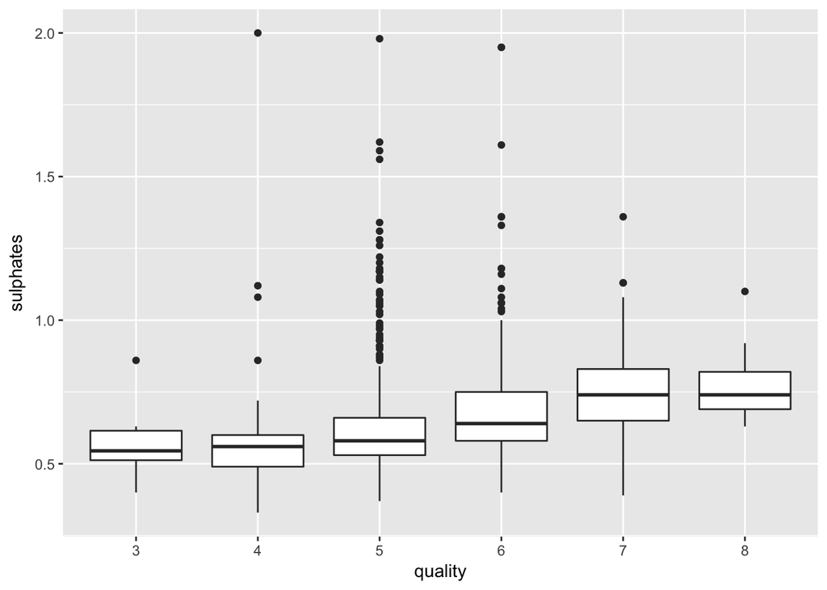

```r
plot_quality_vs_var('sulphates')
```

The higher the quality, the higher the sulphates.

## 4.11 Quality vs Alcohol

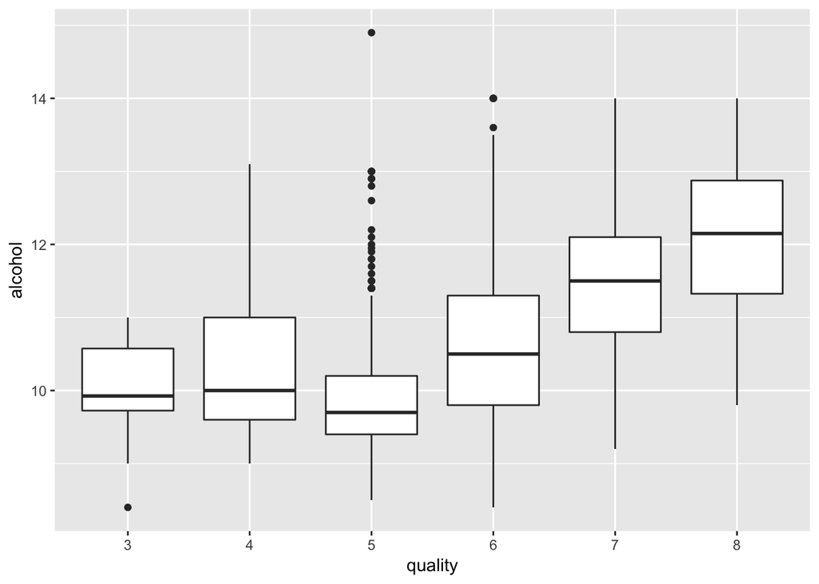

```r
plot_quality_vs_var('alcohol')
```

The higher the quality, the higher the alcohol.